# Mid Term

Siddhant Thakur

#### 1. Map the delay by destination.

Compute the average delay by destination, then join on the airports data frame so you can show the spatial distribution of delays. Here’s an easy way to draw a map of the United States. You are welcome to use this code or some other code.

```r
library(tidyverse)
library(nycflights13)
library(maps)
```

You might want to use the size or colour of the points to display the average delay for each airport.

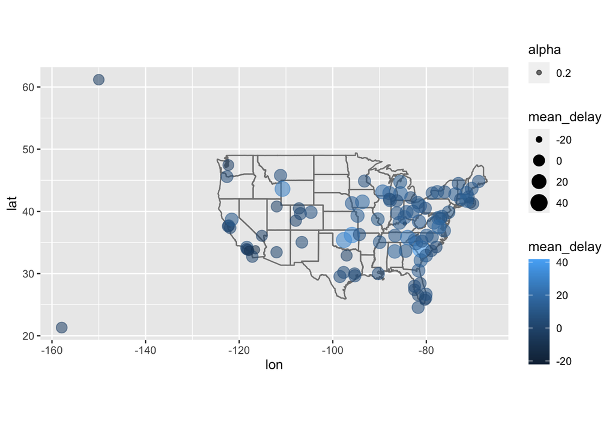

```r
#flights
#planes
#airlines
#airports
#weather

# put your answer here.

flights %>%
  group_by(dest) %>%
  summarise(mean_delay=mean(arr_delay,na.rm=TRUE)) %>%
  left_join(airports,by=c("dest"="faa"))%>%
  ggplot(aes(lon,lat)) +
  borders("state") +
  geom_point(aes(size = mean_delay, color=mean_delay,alpha=0.2)) +
  coord_quickmap()
```

#### 2. Do planes trade ownership?

You might expect that there’s an implicit relationship between plane and airline, because each plane is flown by a single airline. Explore this conjecture using data. (Let’s assume that the tail number of a plane does not change.)

```r
# put your answer here.

# this data contains all the trips made by the that plane and the airline controlling it
plane_carrier <-flights %>%
  group_by(tailnum,carrier) %>%
  summarise(trips_made=n()) %>%
  drop_na()

plane_carrier
```

```
## # A tibble: 4,060 x 3
## # Groups:   tailnum [4,043]
##    tailnum carrier trips_made
##    <chr>   <chr>        <int>
##  1 D942DN  DL               4
##  2 N0EGMQ  MQ             371
##  3 N10156  EV             153
##  4 N102UW  US              48
##  5 N103US  US              46
##  6 N104UW  US              47
##  7 N10575  EV             289
##  8 N105UW  US              45
##  9 N107US  US              41
## 10 N108UW  US              60
## # … with 4,050 more rows
```

```r
# this data consists of the tailnums which had an ownership change
carrier_change <- plane_carrier %>%
  group_by(tailnum) %>%
  summarise(count=n()) %>%
  filter(count>1) %>%
  unpack()

carrier_change
```

```
## # A tibble: 17 x 2
##    tailnum count
##    <chr>   <int>
##  1 N146PQ      2
##  2 N153PQ      2
##  3 N176PQ      2
##  4 N181PQ      2
##  5 N197PQ      2
##  6 N200PQ      2
##  7 N228PQ      2
##  8 N232PQ      2
##  9 N933AT      2
## 10 N935AT      2
## 11 N977AT      2
## 12 N978AT      2
## 13 N979AT      2
## 14 N981AT      2
## 15 N989AT      2
## 16 N990AT      2
## 17 N994AT      2
```

```r
ev_and_9e <- plane_carrier %>%
  filter(tailnum %in% c("N146PQ","N153PQ","N176PQ","N181PQ","N197PQ","N200PQ","N228PQ","N232PQ")) %>%
  pivot_wider(names_from = carrier,values_from = trips_made)
ev_and_9e
```

```
## # A tibble: 8 x 3
## # Groups:   tailnum [8]
##   tailnum  `9E`    EV
##   <chr>   <int> <int>
## 1 N146PQ      8    36
## 2 N153PQ      5    26
## 3 N176PQ      7    21
## 4 N181PQ      4    35
## 5 N197PQ      2    31
## 6 N200PQ      7    28
## 7 N228PQ      8    20
## 8 N232PQ      7    35
```

```r
dl_and_fl <- plane_carrier %>%
  filter(tailnum %in% c("N933AT","N935AT","N977AT","N978AT","N979AT","N981AT","N989AT","N990AT","N994AT")) %>%
  pivot_wider(names_from = carrier,values_from = trips_made)
dl_and_fl
```

```
## # A tibble: 9 x 3
## # Groups:   tailnum [9]
##   tailnum    DL    FL
##   <chr>   <int> <int>
## 1 N933AT     25    10
## 2 N935AT     77    11
## 3 N977AT     62    24
## 4 N978AT     43    22
## 5 N979AT     39    19
## 6 N981AT     22    22
## 7 N989AT     42    24
## 8 N990AT     57    14
## 9 N994AT      9    22
```

```r
filter(airlines, carrier %in% c("9E","EV","DL","FL"))
```

```
## # A tibble: 4 x 2
##   carrier name
##   <chr>   <chr>
## 1 9E      Endeavor Air Inc.
## 2 DL      Delta Air Lines Inc.
## 3 EV      ExpressJet Airlines Inc.
## 4 FL      AirTran Airways Corporation
```

We see that there has been a trade of ownership of some planes between Endeavor Air Inc to ExpressJet Airlines Inc. and Delta AirLines to AirTran Airways Corporation or vice versa,

#### 3a. Plane’s average speed.

Notice that `flights$air_time` is in minutes. Make a new column that is the air time in hours.

```r
# put your answer here.
new_flights <- flights %>%
  mutate(air_time_hour=round(air_time/60,digits=2))

new_flights
```

```
## # A tibble: 336,776 x 20
##     year month   day dep_time sched_dep_time dep_delay arr_time sched_arr_time
##    <int> <int> <int>    <int>          <int>     <dbl>    <int>          <int>
##  1  2013     1     1      517            515         2      830            819
##  2  2013     1     1      533            529         4      850            830
##  3  2013     1     1      542            540         2      923            850
##  4  2013     1     1      544            545        -1     1004           1022
##  5  2013     1     1      554            600        -6      812            837
##  6  2013     1     1      554            558        -4      740            728
##  7  2013     1     1      555            600        -5      913            854
##  8  2013     1     1      557            600        -3      709            723
##  9  2013     1     1      557            600        -3      838            846
## 10  2013     1     1      558            600        -2      753            745
## # … with 336,766 more rows, and 12 more variables: arr_delay <dbl>,
## #   carrier <chr>, flight <int>, tailnum <chr>, origin <chr>, dest <chr>,
## #   air_time <dbl>, distance <dbl>, hour <dbl>, minute <dbl>, time_hour <dttm>,
## #   air_time_hour <dbl>
```

#### 3b. Average speed

For each flight, compute the average speed of that flight (in miles per hour). Then, for each plane, compute the average of those average speeds. Display it in a histogram. You can use a base R histogram `hist` or ggplot’s `geom_histogram`.

```r
# put your answer here.
plane_avg_speed <- new_flights %>%
  mutate(flight_speed = round(distance/air_time_hour,digits=2)) %>%
  group_by(tailnum) %>%
  summarise(mean_average_speed = mean(flight_speed,na.rm=TRUE))

plane_avg_speed
```

```
## # A tibble: 4,044 x 2
##    tailnum mean_average_speed
##    <chr>                <dbl>
##  1 D942DN                382.
##  2 N0EGMQ                391.
##  3 N10156                385.
##  4 N102UW                394.
##  5 N103US                388.
##  6 N104UW                400.
##  7 N10575                356.
##  8 N105UW                383.
##  9 N107US                391.
## 10 N108UW                398.
## # … with 4,034 more rows
```

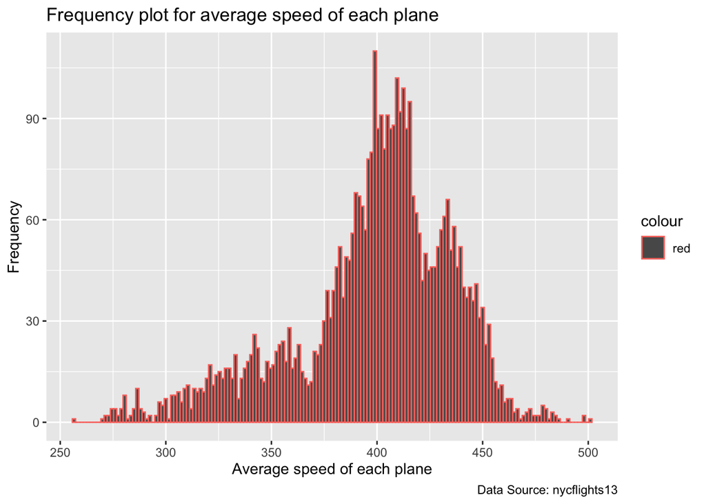

```r
ggplot(plane_avg_speed,aes(mean_average_speed,color='red')) +
  geom_histogram(binwidth = 1.5,na.rm=TRUE) +
  labs(x = "Average speed of each plane",
       y = "Frequency",
       title = "Frequency plot for average speed of each plane",
       caption = "Data Source: nycflights13")
```

#### 4. Bonus

Make a table where each row is a destination, each column is a carrier, and each element is the number of times that the carrier has flown to that destination. Ensure that you only count flights that arrived at the destination.

```r
# put answer here
flights %>%
  drop_na() %>%
  group_by(dest,carrier) %>%
  summarise(trips_made=n()) %>%
  pivot_wider(names_from = carrier,values_from = trips_made)
```

```
## # A tibble: 104 x 17
## # Groups:   dest [104]
##    dest     B6    EV    UA  `9E`    DL    FL    MQ    WN    AA    US    OO    YV
##    <chr> <int> <int> <int> <int> <int> <int> <int> <int> <int> <int> <int> <int>
##  1 ABQ     254    NA    NA    NA    NA    NA    NA    NA    NA    NA    NA    NA
##  2 ACK     264    NA    NA    NA    NA    NA    NA    NA    NA    NA    NA    NA
##  3 ALB      NA   418    NA    NA    NA    NA    NA    NA    NA    NA    NA    NA
##  4 ANC      NA    NA     8    NA    NA    NA    NA    NA    NA    NA    NA    NA
##  5 ATL      NA  1656   102    56 10452  2278  2235    58    NA    NA    NA    NA
##  6 AUS     742    NA   664     2   352    NA    NA   293   358    NA    NA    NA
##  7 AVL      NA   251    NA    10    NA    NA    NA    NA    NA    NA    NA    NA
##  8 BDL      NA   405     7    NA    NA    NA    NA    NA    NA    NA    NA    NA
##  9 BGR      NA   358    NA    NA    NA    NA    NA    NA    NA    NA    NA    NA
## 10 BHM      NA   269    NA    NA    NA    NA    NA    NA    NA    NA    NA    NA
## # … with 94 more rows, and 4 more variables: F9 <int>, HA <int>, VX <int>,
## #   AS <int>
```